# STA141A Final Project: COVID-19 Data

Oh Seung Kwon, 917090323

12MAR2022

# 1 Abstract

In this project, we will look at 8 different sections in order to create a confirmation of the observations we made in a test. Because our main topic of interest in our report is based upon COVID-19, we will have a lot of real world implications that our dataset will compose of. Our introduction will include similar tests and the questions of interests.These tests and questions of interests should provide meaningful analysis to how this can affect real world situations and the basis that can help promote future scientific studies. We will also include background information of how this study will be conducted. This includes the explanation behind why this type of information will allows us to come to a conclusion in our key interests and questions of interests. Three types of analysis can be conducted in order to create a conclusion to our study based on our null and alternative hypothesis. These analysis methods includes descriptive analysis, inferential analysis, and sensitive analysis. Lastly after our conclusion, we will be able to discuss its impact on our study, any errors that were come across, and future recommendations. Not only will our discussion include any recommendations that may have influenced our data set, but how we can further provide assistance to any future reports that will occur.

# 2 Introduction

COVID-19 is an ongoing pandemic that keeps affecting our society to this day. The first cases of COVID-19 was evident in Wuhan, China, and during 2020 these cases started spreading around the world.(Reference 1) Since then, the World Health Organization has been collecting data regarding COVID cases and deaths. This type of analysis is extremely important in finding a vaccine that can cure COVID because without proper analysis we cannot see if the vaccine displays an actual result into lowering COVID cases and death.

The main premise of this study is to see if a countries with similar populations show similar or differing cases when it comes to COVID daily cases of infection and death. The intuition behind this study is to provide further assistance to future and/or existing studies about how a countries population can affect the amount of COVID cases and death daily. This type of information can provide those countries in the danger area to provide more assistance, testing, and vaccination for their citizens to help combat the virus.

# 3 Questions of Interest

1.) Will one of the two countries with similar populations have a significant effect on the number of new cases and deaths every day?

# 4 Background

Our COVID data set contains analysis of COVID cases per country from the dates of 03JAN2020 to 17FEB2022. Our data set includes the date reported, country code, country, WHO region, new COVID cases per date, cumulative COVID cases, new death rates, and cumulative deaths. Although our data has been presented to us through the World Health Organization, these numbers are subject to bias based on the number of testing a country does and if the country is truly giving correct numbers to the WHO. (Reference 3)

Based on (Reference 2), we can see that the United Kingdom and France both have very similar population numbers at around 65,000,000 people for both countries. For this reason, we can use the UK and France as our subjects of interests for the two countries.

# 5 Descriptive analysis

```r
library(tidyverse)
Covid <- read.csv("~/Downloads/WHO-COVID-19-global-data.csv")
```

Based on our data, France began to receive new infection cases of COVID-19 among their populace in 24JAN2020. The UK got their first infection cases of COVID-19 on 01FEB2020. These dates are only different by one week so they are fairly similar.

```r
France = filter(Covid, Country == "France")
UK = filter(Covid, Country == "The United Kingdom")
France
```

| Date_reported | Country_code | Country | WHO_region | New_cases | Cumulative_cases | New_deaths | Cumulative_deaths |
| --- | --- | --- | --- | --- | --- | --- | --- |
| 2020-01-03 | FR | France | EURO | 0 | 0 | 0 | 0 |
| 2020-01-04 | FR | France | EURO | 0 | 0 | 0 | 0 |
| 2020-01-05 | FR | France | EURO | 0 | 0 | 0 | 0 |
| 2020-01-06 | FR | France | EURO | 0 | 0 | 0 | 0 |
| 2020-01-07 | FR | France | EURO | 0 | 0 | 0 | 0 |
| 2020-01-08 | FR | France | EURO | 0 | 0 | 0 | 0 |
| 2020-01-09 | FR | France | EURO | 0 | 0 | 0 | 0 |
| 2020-01-10 | FR | France | EURO | 0 | 0 | 0 | 0 |
| 2020-01-11 | FR | France | EURO | 0 | 0 | 0 | 0 |
| 2020-01-12 | FR | France | EURO | 0 | 0 | 0 | 0 |

[output cut: 767 more lines]

```r
UK
```

| Date_reported | Country_code | Country | WHO_region | New_cases | Cumulative_cases | New_deaths | Cumulative_deaths |
| --- | --- | --- | --- | --- | --- | --- | --- |
| 2020-01-03 | GB | The United Kingdom | EURO | 0 | 0 | 0 | 0 |
| 2020-01-04 | GB | The United Kingdom | EURO | 0 | 0 | 0 | 0 |
| 2020-01-05 | GB | The United Kingdom | EURO | 0 | 0 | 0 | 0 |
| 2020-01-06 | GB | The United Kingdom | EURO | 0 | 0 | 0 | 0 |
| 2020-01-07 | GB | The United Kingdom | EURO | 0 | 0 | 0 | 0 |
| 2020-01-08 | GB | The United Kingdom | EURO | 0 | 0 | 0 | 0 |
| 2020-01-09 | GB | The United Kingdom | EURO | 0 | 0 | 0 | 0 |
| 2020-01-10 | GB | The United Kingdom | EURO | 0 | 0 | 0 | 0 |
| 2020-01-11 | GB | The United Kingdom | EURO | 0 | 0 | 0 | 0 |
| 2020-01-12 | GB | The United Kingdom | EURO | 0 | 0 | 0 | 0 |

[output cut: 767 more lines]

As stated before, our dataset consists of the COVID cases date reported from January 03,2020 to February 17, 2022. We can distinguish the two groups through the country that is being reported through their country code and country name. The data that is supplying our report is from the World Health Organization centered in Europe. We can also see any reports of new COVID infection cases, cumulative infection cases, new deaths related to COVID, and cumulative death cases through COVID.

```r
datatest = select(Covid, Country, New_cases, New_deaths)
Data = filter(datatest, Country == c("France", "The United Kingdom"))
Data
```

| Country | New_cases | New_deaths |
| --- | --- | --- |
| France | 0 | 0 |
| France | 0 | 0 |
| France | 0 | 0 |
| France | 0 | 0 |
| France | 0 | 0 |
| France | 0 | 0 |
| France | 0 | 0 |
| France | 0 | 0 |
| France | 0 | 0 |
| France | 0 | 0 |

[output cut: 768 more lines]

This is a filtered data set that we will use for our inferential analysis.

```r
New_cases_France = select(France, New_cases)
France_summary = summary(New_cases_France)
France_summary
```

```
##    New_cases
##  Min.   :     0
##  1st Qu.:  1269
##  Median :  7124
##  Mean   : 27470
##  3rd Qu.: 21386
##  Max.   :500563
```

From this 5 number summary for the amount of new COVID cases in France, we can see that the mean value of number of new infection cases for COVID are 27,470 cases in France per day. France also has a huge max numbers of new cases in a day which is 500563.

```r
New_cases_UK = select(UK, New_cases)
UK_summary = summary(New_cases_UK)
UK_summary
```

```
##    New_cases
##  Min.   :     0
##  1st Qu.:  2014
##  Median : 10069
##  Mean   : 23742
##  3rd Qu.: 34384
##  Max.   :273487
```

From this 5 number summary for the amount of new COVID cases in the UK, we can see that the mean value of number of new infection cases for COVID are 23,742 cases in the UK per day. The UKs max number of cases in one day is 273487 which is alot lower than Frances max.

```r
New_deathcases_France = select(France, New_deaths)
Francedeath_summary = summary(New_deathcases_France)
Francedeath_summary
```

```
##    New_deaths
##  Min.   : -27
##  1st Qu.:  22
##  Median :  82
##  Mean   : 171
##  3rd Qu.: 256
##  Max.   :2003
```

For our 5 number summary regarding deaths relating to COVID for France, we can see that France had an average of 171 deaths per day.

```r
New_deathcases_UK = select(UK, New_deaths)
UKdeath_summary = summary(New_deathcases_UK)
UKdeath_summary
```

```
##    New_deaths
##  Min.   :   0
##  1st Qu.:  17
##  Median :  85
##  Mean   : 206
##  3rd Qu.: 254
##  Max.   :1820
```

For our 5 number summary regarding deaths relating to COVID for the UK, we can see that the UK had an average of 206 deaths per day.

Based on our 5 number summaries on locating the average number of new COVID infection cases and deaths per day, we can see differing viewpoints. For example, France had a higher new COVID infection rate per day than the UK, however the UK had a higher death rate due to COVID than France. This can maybe be explained because their may be more people in the UK that are at high risk of COVID relating deaths than in France.

We can also summarize more of our findings when it comes to the overall COVID cases and deaths for both countries.

```r
cases_France = select(France, Cumulative_cases)
casesFrance_summary = summary(cases_France)
casesFrance_summary
```

```
##  Cumulative_cases
##  Min.   :       0
##  1st Qu.:  165387
##  Median : 3003499
##  Mean   : 3879515
##  3rd Qu.: 6116265
##  Max.   :21344186
```

```r
deathcases_France = select(France, Cumulative_deaths)
deathFrancedeath_summary = summary(deathcases_France)
deathFrancedeath_summary
```

```
##  Cumulative_deaths
##  Min.   :     0
##  1st Qu.: 29928
##  Median : 72656
##  Mean   : 68251
##  3rd Qu.:111039
##  Max.   :132883
```

Frances cumulative cases had a mean of 3879515 while the cumulative deaths were 68251.

```r
cases_UK = select(UK, Cumulative_cases)
casesUK_summary = summary(cases_UK)
casesUK_summary
```

```
##  Cumulative_cases
##  Min.   :       0
##  1st Qu.:  292448
##  Median : 3731155
##  Mean   : 4181718
##  3rd Qu.: 6162575
##  Max.   :18447710
```

```r
deathcases_UK = select(UK, Cumulative_deaths)
deathUKdeath_summary = summary(deathcases_UK)
deathUKdeath_summary
```

```
##  Cumulative_deaths
##  Min.   :     0
##  1st Qu.: 40899
##  Median : 97939
##  Mean   : 84260
##  3rd Qu.:130178
##  Max.   :160038
```

We can further examine any analysis of our data through a visual aid. This can be done through graphing our data based on the time reported. Because there is more than 500 times observed, we will have to rely on the graph to see the shape and relationship of the COVID new and cumulative infection cases and new and cumulative deaths per country.

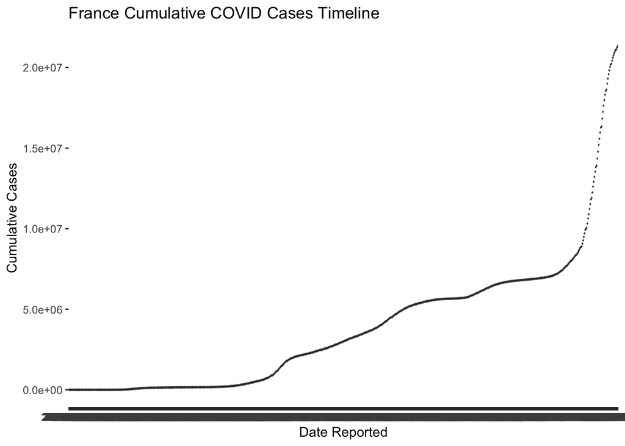

```r
ggplot(data=France, mapping=aes(x=Date_reported, y=Cumulative_cases)) +
  geom_boxplot() +
  xlab("Date Reported") +
  ylab("Cumulative Cases") +
  ggtitle("France Cumulative COVID Cases Timeline")
```

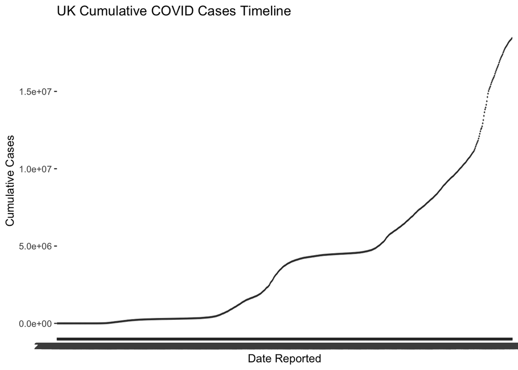

```r
ggplot(data=UK, mapping=aes(x=Date_reported, y=Cumulative_cases)) +
  geom_boxplot() +
  xlab("Date Reported") +
  ylab("Cumulative Cases") +
  ggtitle("UK Cumulative COVID Cases Timeline")
```

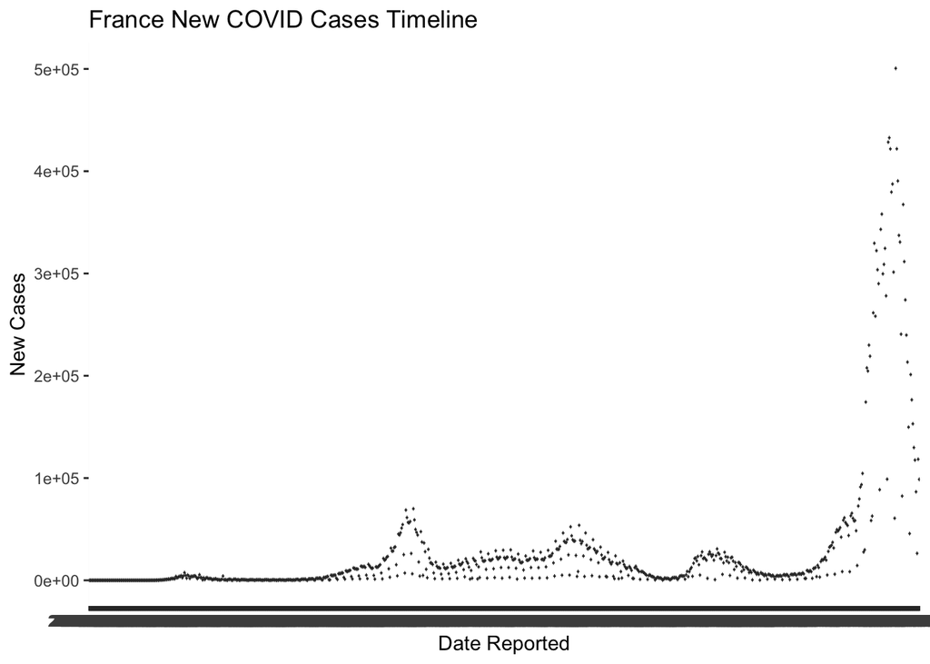

```r
ggplot(data=France, mapping=aes(x=Date_reported, y=New_cases)) +
  geom_boxplot() +
  xlab("Date Reported") +
  ylab("New Cases") +
  ggtitle("France New COVID Cases Timeline")
```

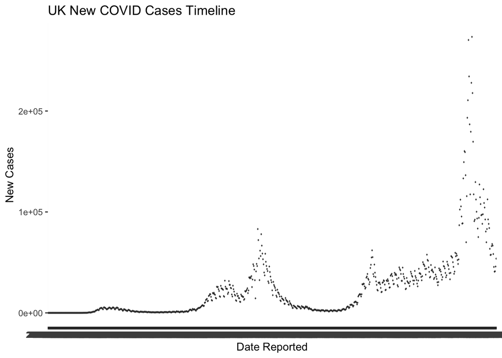

```r
ggplot(data=UK, mapping=aes(x=Date_reported, y=New_cases)) +
  geom_boxplot() +
  xlab("Date Reported") +
  ylab("New Cases") +
  ggtitle("UK New COVID Cases Timeline")
```

Based on our plots for the new and cumulative COVID cases recorded based on time for France and the UK, we can see that they both share an exponential type of relationship for cumulative cases. The new cases for both countries shows several spikes depending on the date reported.

We can also look at the relationships on time and deaths for new and cumulative for both countries.

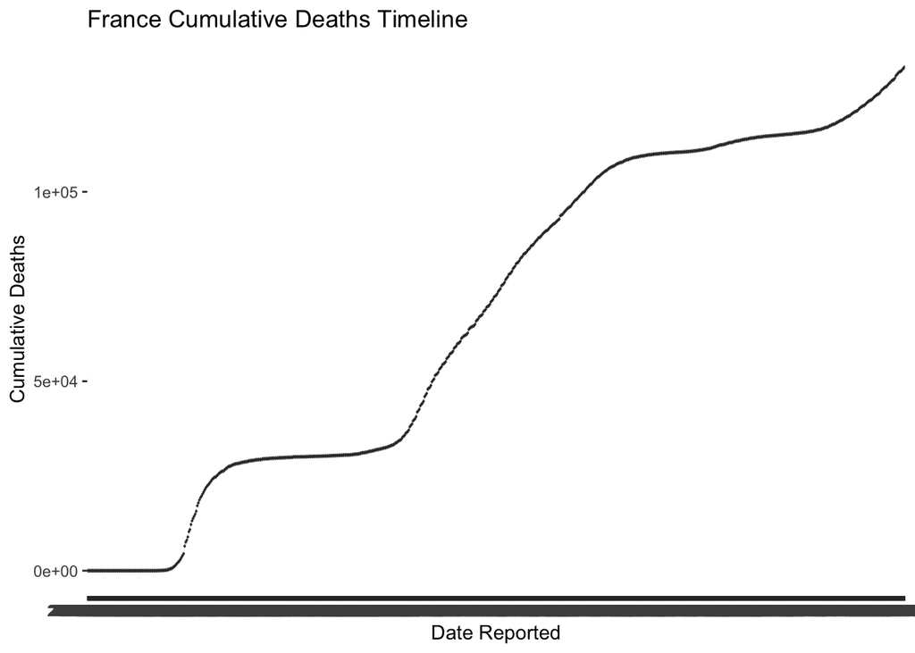

```r
ggplot(data=France, mapping=aes(x=Date_reported, y=Cumulative_deaths)) +
  geom_boxplot() +
  xlab("Date Reported") +
  ylab("Cumulative Deaths") +
  ggtitle("France Cumulative Deaths Timeline")
```

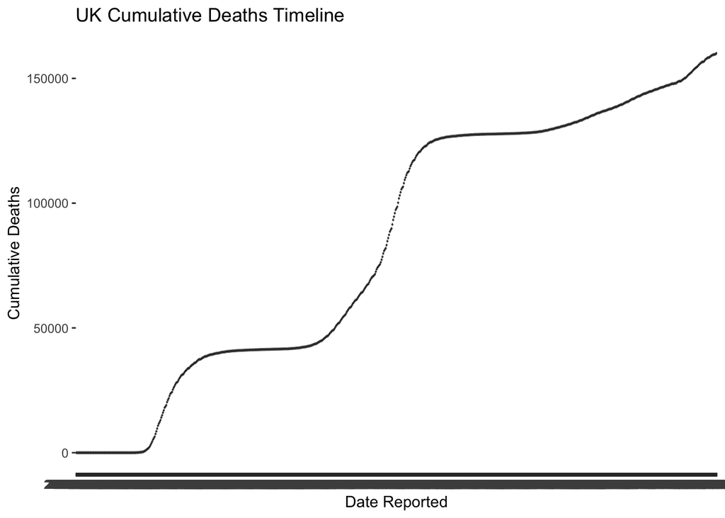

```r
ggplot(data=UK, mapping=aes(x=Date_reported, y=Cumulative_deaths)) +
  geom_boxplot() +
  xlab("Date Reported") +
  ylab("Cumulative Deaths") +
  ggtitle("UK Cumulative Deaths Timeline")
```

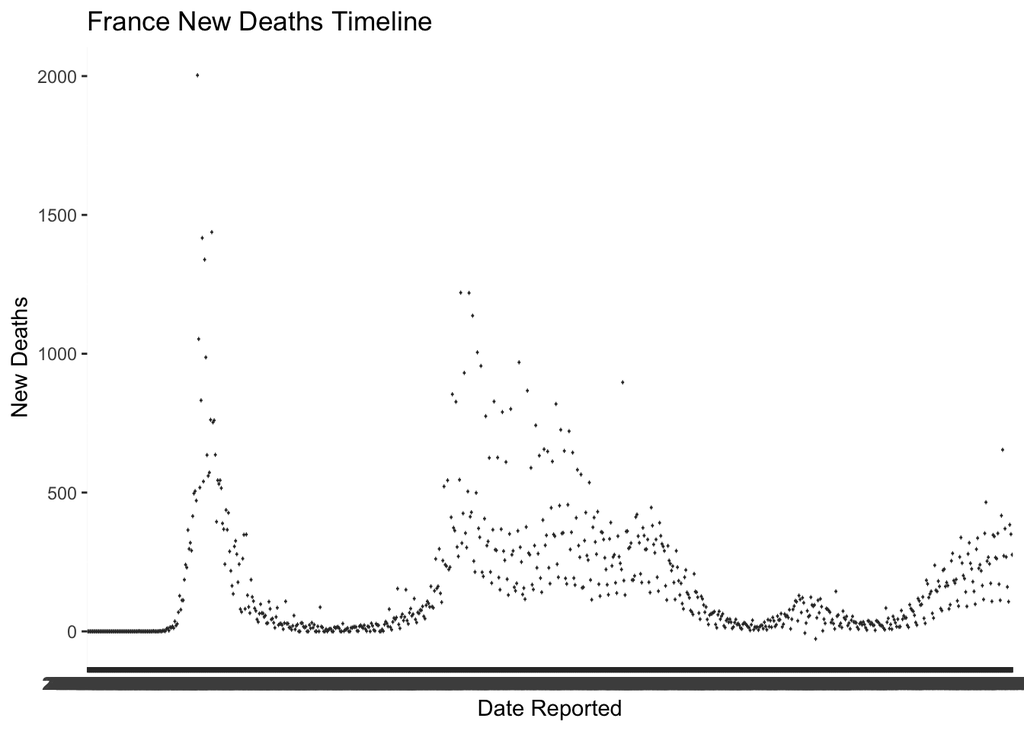

```r
ggplot(data=France, mapping=aes(x=Date_reported, y=New_deaths)) +
  geom_boxplot() +
  xlab("Date Reported") +
  ylab("New Deaths") +
  ggtitle("France New Deaths Timeline")
```

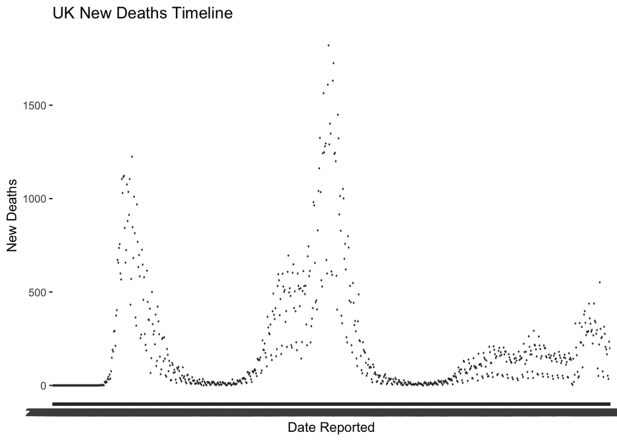

```r
ggplot(data=UK, mapping=aes(x=Date_reported, y=New_deaths)) +
  geom_boxplot() +
  xlab("Date Reported") +
  ylab("New Deaths") +
  ggtitle("UK New Deaths Timeline")
```

The cumulative deaths for both countries have a similar shape when they are plotted. However, the new death cases show much more abnormal spikes than the new cumulative cases for both countries.

Based on our visual observations, it seems as if France has a larger average of new COVID cases while the UK has a larger average of new COVID related deaths.

# 6 Inferential analysis

For inferential analysis, I plan to use two models to conduct analysis of our study. These will include the One Way ANOVA Test and Tukey’s HSD test if the main effect is significant so that we can find the significant country. We will use the One Way ANOVA test because we only have one variable that we want to test which is the country and its effects on the new cases.

The assumptions for the One Way ANOVA Test includes that the populations of our study is normally distributed and equal variance. Our Tukey’s HSD test assumes that we have random independent samples and our population has normal distribution.

Our hypothesis are as follows, and we will assume our significance level (a) is 0.05.

H0 = main effects are no significant Ha = main effects are significant

We can test for these effects through the one way ANOVA model because we want to find out if the country of origin has a significant effect.

For our one way ANOVA model, we can propose the following model: Yij = ui + eij

```r
model = aov(New_cases~Country , data = Data)
summary(model)
```

```
##              Df    Sum Sq   Mean Sq F value Pr(>F)
## Country       1 2.957e+09 2.957e+09   1.006  0.316
## Residuals   776 2.280e+12 2.938e+09
```

Because our p-value is 0.316, and which is larger than our significance level of 0.05. We do not have enough evidence to reject our null hypothesis. We can conclude that for COVID cases, the country of origin does not have a significant effect.

However, we can also find out if the countries has a significant effect on the new death rates by COVID. We will do a one way ANOVA test for the new death reports as well.

```r
model1 = aov(New_deaths~Country , data = Data)
summary(model1)
```

```
##              Df   Sum Sq Mean Sq F value Pr(>F)
## Country       1   172390  172390   2.363  0.125
## Residuals   776 56606885   72947
```

We are keeping the same hypothesis and significance level. Based on our ANOVA test, we get a p value of 0.125.

Because our p value is larger than our significance level of 0.05, we do not have enough evidence to reject our null hypothesis. Again, we can conclude that the country does not have an effect on COVID death rates.

# 7 Sensitivity analysis

Now, we can start to make our residual plots of our fitted values.

Our first plot is regarding the new covid cases for both countries (UK and France)

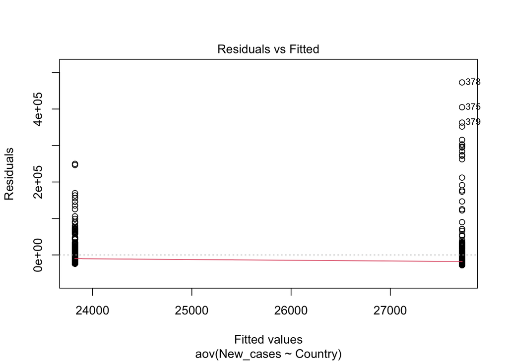

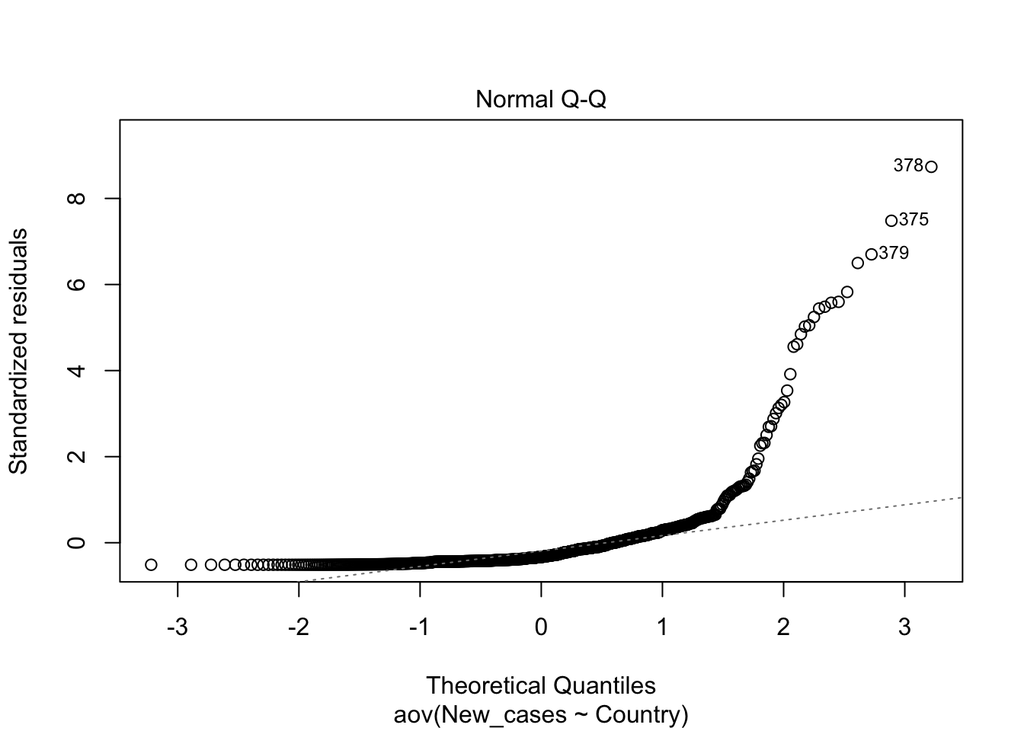

```
## hat values (leverages) are all = 0.002570694
##  and there are no factor predictors; no plot no. 5
```

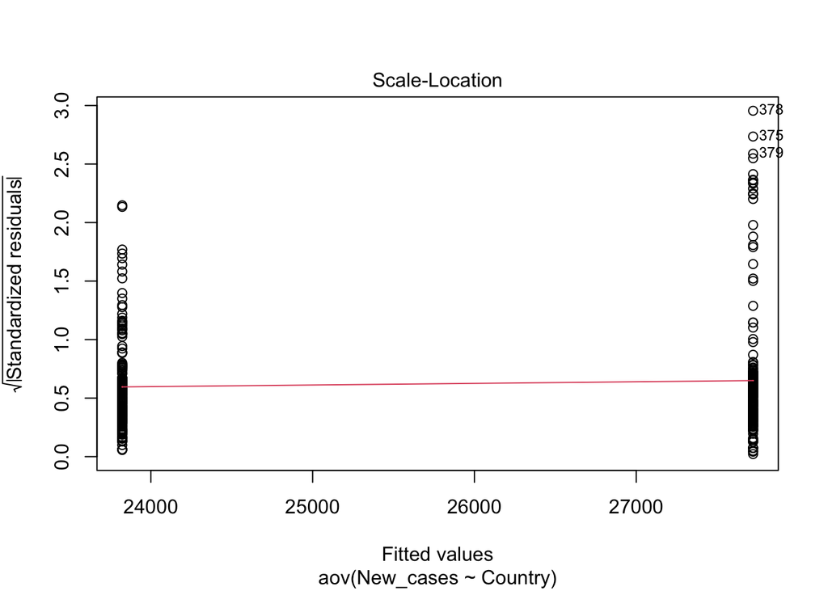

```r
plot(model)
```